# Danielson Against other Metrics

## Comparing the metrics

In this piece, we’ll start comparing across different metrics of teacher success.

- The Disposition score of the student’s most important college class (modified using the same z-score method as Danielson)
- Whether or not they received Idaho teacher certification
- How well the student did on their Praxis exams relative to their peers (not just if they passed, but by what margin)
- Surveys from the principal, evaluating that student’s effectiveness in the classroom as a teacher
- Surveys from the student themselves with the same questions.

```r
library(tidyverse)
library(arrow)
library(ResourceSelection)
library(ggpubr)
library(pander)

all <- read_parquet("../../Scripts/All_teacher_info.parquet") %>%
  filter(!is.na(WDanielson_highest_level)) %>%
  select(StudentID,WDanielson_highest_level,Disposition_highest_level,Prax_avg_zscore,certification,
         employer_survey_total,self_survey_total)

all %>%
  arrange(self_survey_total) %>%
  drop_na() %>%
  head(5) %>%
  pander()
```

Table continues below

| StudentID | WDanielson_highest_level | Disposition_highest_level |
| --- | --- | --- |
| 321561 | -0.153 | -0.227 |
| 326583 | 0.549 | 0.158 |
| 387828 | -0.852 | -0.227 |
| 374437 | -2.109 | -0.257 |
| 327641 | 1.276 | 0.07 |

| Prax_avg_zscore | certification | employer_survey_total | self_survey_total |
| --- | --- | --- | --- |
| 1.135 | 1 | 3 | 1.812 |
| -0.209 | 1 | 3 | 1.875 |
| 0.44 | 1 | 2.125 | 2 |
| 1.54 | 1 | 2.438 | 2.375 |
| -0.565 | 1 | 3 | 2.562 |

### Danielson & Z-Score

This analysis builds off the aggregation of Danielson observations recorded in [this article](https://sites.google.com/view/benjamin-pacini/dissertation/data-overview/danielson-fft?authuser=0).  
In summary, we’ve condensed down the Danielson observations across dozens of classes and individual reports based on three criteria:

1. We’ve prioritized observations from the classes furthest along in the student’s career. For most students, we use their scores from ED 492, but for those missing observations, we use any other 400-level, then 300- and 200-level class.
2. If a student has more than one observation recorded for the class, we prioritize the summative evaluations over the formative ones.
3. To compensate for different grading standards across teachers, we’ve turned each raw final score (a 3-pt scale of 22 questions) into a z_score. Now each score reflects how the student did in this class compared to their peers.-

$$zscore = \frac{x_{StudentScore} - \mu_{TeacherAndSemester}}{\sigma_{TeacherAndSemester}}$$
After these steps, we go from 9854 individual observations to 1776 values tied to student records.

Unfortunately, only 23 of our 1776 potential teachers received all 6 of these summative evaluations. As a result, each of these smaller analysis will use different sub-sections of these 1776 students.

It’s important to notice that because we made all these adjustments from the raw observations, this analysis won’t be useful for predicting individual scores. This can only tell which other metrics are most likely to help students succeed.

## Danielson against Disposition

```r
lm_dan_disp <- lm(WDanielson_highest_level ~ Disposition_highest_level, data = all)
summary(lm_dan_disp) %>% pander::pander()
```

|  | Estimate | Std. Error | t value | Pr(>\|t\|) |
| --- | --- | --- | --- | --- |
| **(Intercept)** | -0.04852 | 0.02299 | -2.11 | 0.03498 |
| **Disposition_highest_level** | 0.3323 | 0.02399 | 13.85 | 2.167e-41 |

Fitting linear model: WDanielson_highest_level ~ Disposition_highest_level

| Observations | Residual Std. Error | $R^2$ | Adjusted $R^2$ |
| --- | --- | --- | --- |
| 1678 | 0.9413 | 0.1027 | 0.1022 |

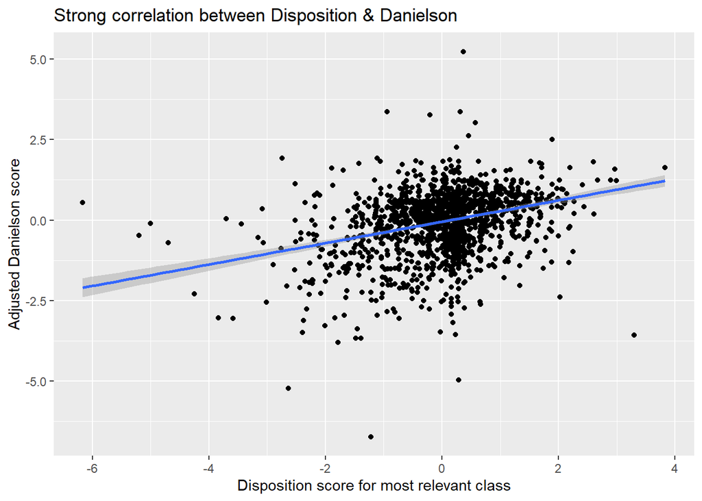

```r
ggplot(all,aes(x=Disposition_highest_level,y=WDanielson_highest_level)) +
  geom_jitter() +
  geom_smooth(method = 'lm') +
  labs(x='Disposition score for most relevant class',y='Adjusted Danielson score',
    title="Strong correlation between Disposition & Danielson")
```

## Danielson against Praxis z-score

Again, we’ve re-scored the Praxis exams to reflect the varied difficulty of various tests and how well the student did on the exam, more than just a raw pass.

```r
lm_dan_prax <- lm(WDanielson_highest_level ~ Prax_avg_zscore, data = all)
summary(lm_dan_prax) %>% pander::pander()
```

|  | Estimate | Std. Error | t value | Pr(>\|t\|) |
| --- | --- | --- | --- | --- |
| **(Intercept)** | -0.001741 | 0.02634 | -0.0661 | 0.9473 |
| **Prax_avg_zscore** | 0.06757 | 0.03022 | 2.236 | 0.0255 |

Fitting linear model: WDanielson_highest_level ~ Prax_avg_zscore

| Observations | Residual Std. Error | $R^2$ | Adjusted $R^2$ |
| --- | --- | --- | --- |
| 1326 | 0.9593 | 0.003763 | 0.00301 |

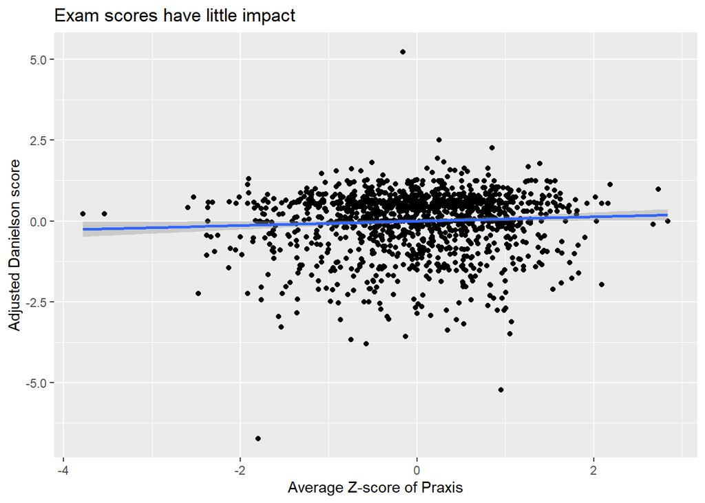

```r
ggplot(all,aes(x=Prax_avg_zscore,y=WDanielson_highest_level)) +
  geom_point() +
  geom_smooth(method = 'lm') +
  labs(x='Average Z-score of Praxis',y='Adjusted Danielson score',
    title="Exam scores have little impact")
```

## Danielson against Certification

Many students who take Danielsons don’t certify for various reasons: they don’t plan to teach in Idaho, they switch majors, or they fail Praxis exams.

```r
all_cert = all %>% filter(certification!=0.5) %>% mutate(certification=ifelse(certification==0,'Did Not Certify','Certified'))
lm_dan_act <- lm(WDanielson_highest_level ~ certification, data = all_cert)
summary(lm_dan_act) %>% pander::pander()
```

|  | Estimate | Std. Error | t value | Pr(>\|t\|) |
| --- | --- | --- | --- | --- |
| **(Intercept)** | -0.001075 | 0.03269 | -0.03288 | 0.9738 |
| **certificationDid Not Certify** | -0.04721 | 0.1345 | -0.3511 | 0.7256 |

Fitting linear model: WDanielson_highest_level ~ certification

| Observations | Residual Std. Error | $R^2$ | Adjusted $R^2$ |
| --- | --- | --- | --- |
| 897 | 0.9496 | 0.0001377 | -0.0009795 |

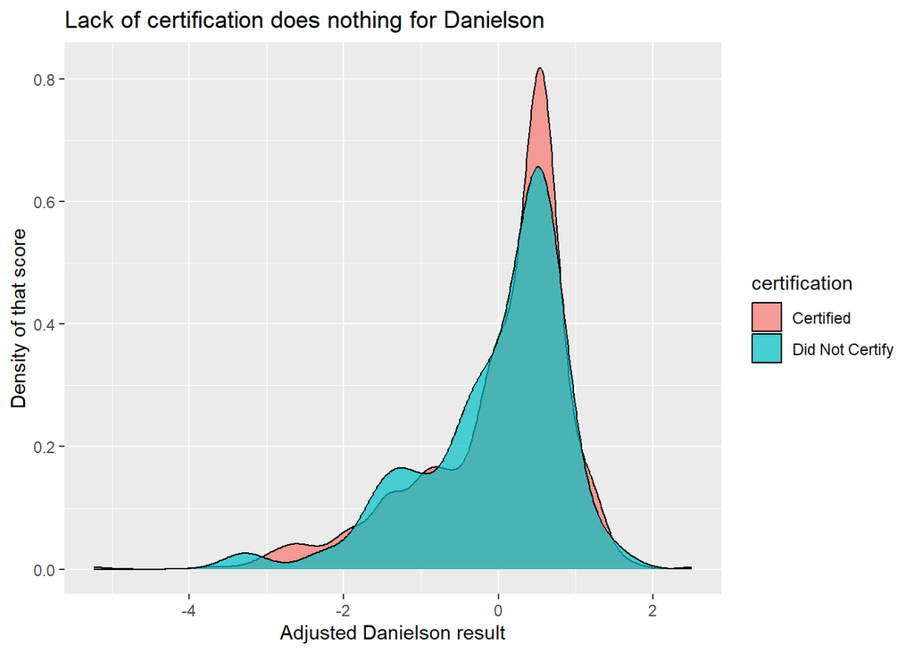

```r
ggplot(all_cert,aes(WDanielson_highest_level,group=certification,fill=certification)) +
  geom_density(alpha=.7) +
  labs(x='Adjusted Danielson result',y='Density of that score',
    title="Lack of certification does nothing for Danielson")
```

## Danielson against Employer Survey

The questions on these two evaluations aren’t quite the same, but they both involve observations within the classroom to measure teacher performance. Unforunately for us, There seems to be no statistically significant relationship between the results for both observations.

```r
lm_dan_emp <- lm(WDanielson_highest_level ~ employer_survey_total,data=all)
summary(lm_dan_emp) %>% pander::pander()
```

|  | Estimate | Std. Error | t value | Pr(>\|t\|) |
| --- | --- | --- | --- | --- |
| **(Intercept)** | -0.4216 | 0.6899 | -0.6111 | 0.5428 |
| **employer_survey_total** | 0.1213 | 0.225 | 0.5389 | 0.5914 |

Fitting linear model: WDanielson_highest_level ~ employer_survey_total

| Observations | Residual Std. Error | $R^2$ | Adjusted $R^2$ |
| --- | --- | --- | --- |
| 85 | 0.9935 | 0.003487 | -0.00852 |

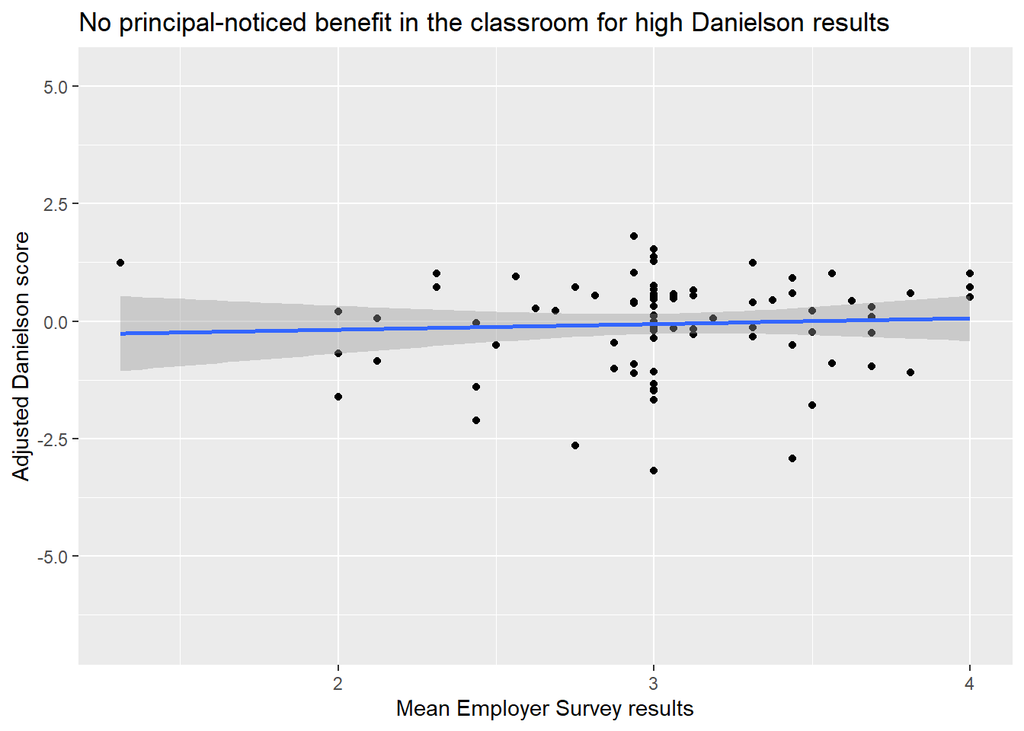

```r
ggplot(all,aes(y=WDanielson_highest_level,x=employer_survey_total)) +
  geom_point() +
  geom_smooth(method='lm')+
  labs(x='Mean Employer Survey results',y='Adjusted Danielson score',
    title="No principal-noticed benefit in the classroom for high Danielson results")  +
  theme(legend.position = 'none')
```

## Danielson against Self-reported Score

The student’s evaluation on these same questions is no better.

```r
lm_dan_emp <- lm(WDanielson_highest_level ~ self_survey_total,data=all)
summary(lm_dan_emp) %>% pander::pander()
```

|  | Estimate | Std. Error | t value | Pr(>\|t\|) |
| --- | --- | --- | --- | --- |
| **(Intercept)** | -0.4929 | 0.4599 | -1.072 | 0.2857 |
| **self_survey_total** | 0.1439 | 0.1506 | 0.9559 | 0.3408 |

Fitting linear model: WDanielson_highest_level ~ self_survey_total

| Observations | Residual Std. Error | $R^2$ | Adjusted $R^2$ |
| --- | --- | --- | --- |
| 139 | 0.9263 | 0.006625 | -0.0006257 |

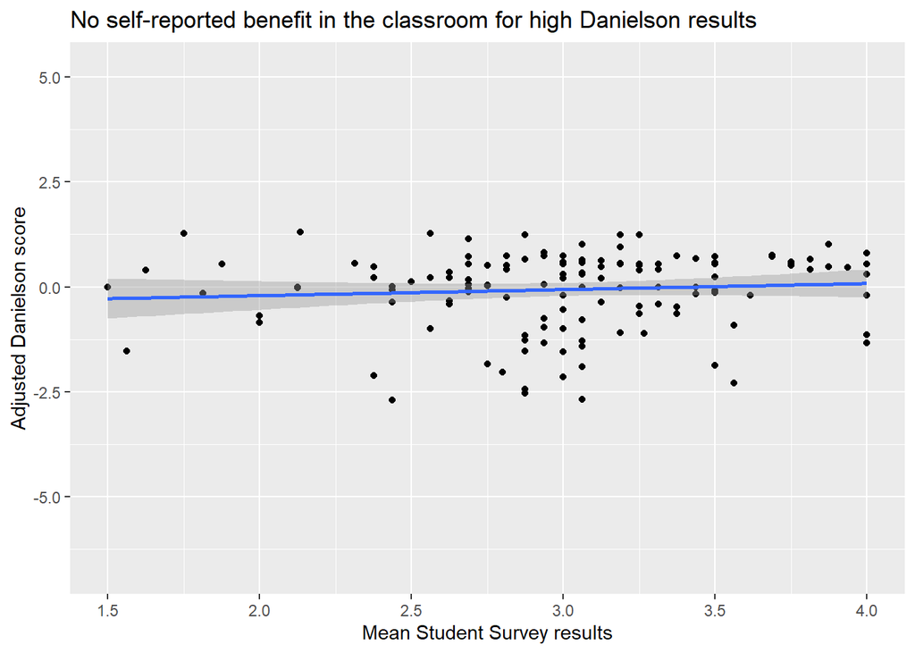

```r
ggplot(all,aes(y=WDanielson_highest_level,x=self_survey_total)) +
  geom_point() +
  geom_smooth(method='lm')+
  labs(x='Mean Student Survey results',y='Adjusted Danielson score',
    title="No self-reported benefit in the classroom for high Danielson results")  +
  theme(legend.position = 'none')
```

## Across all Metrics

As we wrap up, let’s see what insights we can find as we pull all of these different metrics together. Unfortunately, only 23 students have all 6 of these metrics, which gives a very unlikely skew to our results.

```r
all_metrics <- drop_na(all) #now only the people with all metrics
dan_all <- lm(WDanielson_highest_level~Disposition_highest_level+certification+Prax_avg_zscore+self_survey_total+employer_survey_total,data=all_metrics)
summary(dan_all) %>% pander()
```

|  | Estimate | Std. Error | t value | Pr(>\|t\|) |
| --- | --- | --- | --- | --- |
| **(Intercept)** | -1.278 | 1.032 | -1.239 | 0.2312 |
| **Disposition_highest_level** | 0.4281 | 0.2628 | 1.629 | 0.1206 |
| **Prax_avg_zscore** | -0.7537 | 0.2348 | -3.21 | 0.004854 |
| **self_survey_total** | -0.29 | 0.3361 | -0.8628 | 0.3996 |
| **employer_survey_total** | 0.6579 | 0.3674 | 1.791 | 0.09016 |

Fitting linear model: WDanielson_highest_level ~ Disposition_highest_level + certification + Prax_avg_zscore + self_survey_total + employer_survey_total

| Observations | Residual Std. Error | $R^2$ | Adjusted $R^2$ |
| --- | --- | --- | --- |
| 23 | 0.7045 | 0.453 | 0.3315 |

*Certification* disappears because all of these students were certified. In this subsample, only the praxis scores appear statistically significant, but they actually have an opposite effect: high-performing Danielson students are correlated with worse outcomes on Praxis. We can likely blame this on the small sample size.

```r
intercepts = tibble('Factor'=c('Intercept','Disposition_highest_level','certification','Prax_avg_zscore','self_survey_total','employer_survey_total'),
                'Coefficients'=c(dan_all$coefficients))
avg_intercept <- intercepts$Coefficients[[1]]+intercepts$Coefficients[[2]]*mean(all_metrics$Disposition_highest_level) + intercepts$Coefficients[[4]]*mean(all_metrics$self_survey_total)+intercepts$Coefficients[[5]]*mean(all_metrics$employer_survey_total)
all_chart <- ggplot(drop_na(all),aes(x=Prax_avg_zscore,y=WDanielson_highest_level)) + geom_point()
for (row in c(1,2,3,5,6)) {
  all_chart <- all_chart + geom_abline(intercept=intercepts$Coefficients[[ row]],
                                  slope=intercepts$Coefficients[[4]])
}
all_chart
```

[output not shown]